# User Guide: 2 Manipulation of plot layers

‘gginnards’ 0.0.1

Pedro J. Aphalo

2018-07-05

## Introduction

The functions described here are not expected to be useful in everyday plotting as one can simply change the order in which layers are added to a ggplot. However, if one uses high level methods or functions that automatically produce a full plot using ‘ggplot2’ internally, one may need to add, move or delete layers so as to profit from such canned methods and retain enough flexibility.

Some time ago I needed to manipulate the layers of a `ggplot`, and found a matching question in matching question in Stackoverflow. I used the answers found in Stackoverflow as the starting point for writing the functions described in this vignette.

In a `ggplot` object, layers reside in a list, and their positions in the list determine the plotting order when generating the graphical output. The Grammar of Graphics treats the list of layers as a *stack* using only *push* operations. In other words, always the most recently added layer resides at the end of the list, and over-plots all layers previously added. The functions described in this vignette allow overriding the **normal** syntax at the cost of breaking the expectations of the grammar. These functions are, as told above, to be used only in exceptional cases. This notwithstanding, they are rather easy to use. The user interface is consistent across all of them. Moreover, they are designed to return objects that are identical to objects created using the normal syntax rules of the Grammar of Graphics.

| Function | Use |
| --- | --- |
| `delete_layers()` | delete one or more layers |
| `append_layers()` | append layers at a specific position |
| `move_layers()` | move layers to an absolute position |
| `shift_layers()` | move layers to a relative position |
| `which_layers()` | obtain the index positions of layers |
| `extract_layers()` | extract matched or indexed layers |
| `num_layers()` | obtain number of layers |
| `top_layer()` | obtain position of top layer |
| `bottom_layer()` | obtain position of bottom layer |

Although their definitions do not rely on code internal to ‘ggplot2’, they rely on the internal structure of objects belonging to class `gg` and `ggplot`. Consequently, long-term backwards and forward compatibility cannot be guaranteed, or even expected.

## Preliminaries

```r
library(ggplot2)
library(gginnards)
library(tibble)
library(magrittr)
library(stringr)
```

We generate some artificial data.

```r
set.seed(4321)
# generate artificial data
my.data <- data.frame(
  group = factor(rep(letters[1:4], each = 30)),
  panel = factor(rep(LETTERS[1:2], each = 60)),
  y = rnorm(40),
  unused = "garbage"
)
```

We change the default theme to an uncluttered one.

```r
old_theme <- theme_set(theme_bw())
```

We generate a plot to be used later to demonstrate the use of the functions.

```r
p <- ggplot(my.data, aes(group, y)) +
  geom_point() +
  stat_summary(fun.data = mean_se, colour = "red", size = 1.3) +
  facet_wrap(~panel, scales = "free_x", labeller = label_both)
p
```

[output not shown]

## Exploring how ggplots are stored

To display textual information about a `gg` object we use method `summary()`, while methods `print()` and `plot()` will display the actual plot.

```r
summary(p)
```

```
## data: group, panel, y, unused [120x4]
## mapping:  x = ~group, y = ~y
## faceting: <ggproto object: Class FacetWrap, Facet, gg>
##     compute_layout: function
##     draw_back: function
##     draw_front: function
##     draw_labels: function
##     draw_panels: function
##     finish_data: function
##     init_scales: function
##     map_data: function
##     params: list
##     setup_data: function
##     setup_params: function
##     shrink: TRUE
##     train_scales: function
##     vars: function
##     super:  <ggproto object: Class FacetWrap, Facet, gg>
## -----------------------------------
## geom_point: na.rm = FALSE
## stat_identity: na.rm = FALSE
## position_identity
##
## geom_pointrange: na.rm = FALSE
## stat_summary: fun.data = function (x, mult = 1)
## {
##     x <- stats::na.omit(x)
##     se <- mult * sqrt(stats::var(x)/length(x))
##     mean <- mean(x)
##     data.frame(y = mean, ymin = mean - se, ymax = mean + se)
## }, fun.y = NULL, fun.ymax = NULL, fun.ymin = NULL, fun.args = list(), na.rm = FALSE
## position_identity
```

Layers in a ggplot object are stored in a list as nameless members. This means that they have to be accessed using numerical indexes, and that we need to use some indirect way of finding the indexes correspiónding to the layers of interest.

```r
names(p$layers)
```

[output not shown]

The output of `summary()` is compact.

```r
summary(p$layers)
```

```
##      Length Class         Mode
## [1,] 11     LayerInstance environment
## [2,] 11     LayerInstance environment
```

The default `print()` method for a list of layers displays only a small part of the information in a layer.

```r
print(p$layers)
```

```
## [[1]]
## geom_point: na.rm = FALSE
## stat_identity: na.rm = FALSE
## position_identity
##
## [[2]]
## geom_pointrange: na.rm = FALSE
## stat_summary: fun.data = function (x, mult = 1)
## {
##     x <- stats::na.omit(x)
##     se <- mult * sqrt(stats::var(x)/length(x))
##     mean <- mean(x)
##     data.frame(y = mean, ymin = mean - se, ymax = mean + se)
## }, fun.y = NULL, fun.ymax = NULL, fun.ymin = NULL, fun.args = list(), na.rm = FALSE
## position_identity
```

To see all the fields, we need to use `str()`, which we use here for a single layer.

```r
str(p$layers[[1]])
```

```
## Classes 'LayerInstance', 'Layer', 'ggproto', 'gg' <ggproto object: Class LayerInstance, Layer, gg>
##     aes_params: list
##     compute_aesthetics: function
##     compute_geom_1: function
##     compute_geom_2: function
##     compute_position: function
##     compute_statistic: function
##     data: waiver
##     draw_geom: function
##     finish_statistics: function
##     geom: <ggproto object: Class GeomPoint, Geom, gg>
##         aesthetics: function
##         default_aes: uneval
##         draw_group: function
##         draw_key: function
##         draw_layer: function
##         draw_panel: function
##         extra_params: na.rm
##         handle_na: function
##         non_missing_aes: size shape colour
##         optional_aes:
##         parameters: function
##         required_aes: x y
##         setup_data: function
##         use_defaults: function
##         super:  <ggproto object: Class Geom, gg>
##     geom_params: list
##     inherit.aes: TRUE
##     layer_data: function
##     map_statistic: function
##     mapping: NULL
##     position: <ggproto object: Class PositionIdentity, Position, gg>
##         compute_layer: function
##         compute_panel: function
##         required_aes:
##         setup_data: function
##         setup_params: function
##         super:  <ggproto object: Class Position, gg>
##     print: function
##     show.legend: NA
##     stat: <ggproto object: Class StatIdentity, Stat, gg>
##         aesthetics: function
##         compute_group: function
##         compute_layer: function
##         compute_panel: function
##         default_aes: uneval
##         extra_params: na.rm
##         finish_layer: function
##         non_missing_aes:
##         parameters: function
##         required_aes:
##         retransform: TRUE
##         setup_data: function
##         setup_params: function
##         super:  <ggproto object: Class Stat, gg>
##     stat_params: list
##     super:  <ggproto object: Class Layer, gg>
```

## Manipulation of plot layers

We start by using `which_layers()` as it produces simply a vector of indexes into the list of layers. The third statement is useless here, but demonstrates how layers are selected in all the functions described in this document.

```r
which_layers(p, "GeomPoint")
```

```
## [1] 1
```

```r
which_layers(p, "StatSummary")
```

```
## [1] 2
```

```r
which_layers(p, idx = 1L)
```

```
## [1] 1
```

We can also easily extract matching layers with `extract_layers()`. Here one layer is returned, and displayed using the default `print()` method. Method `str()` can also be used as shown above.

```r
extract_layers(p, "GeomPoint")
```

```
## [[1]]
## geom_point: na.rm = FALSE
## stat_identity: na.rm = FALSE
## position_identity
```

With `delete_layers()` we can remove layers from a plot, selecting them using the match to a class, as shown here, or by a positional index. This was shown above for `which_layers()`.

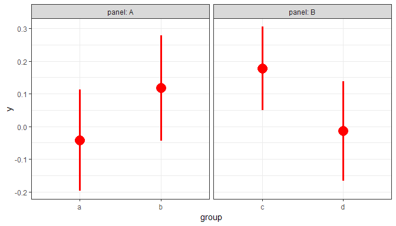

```r
delete_layers(p, "GeomPoint")
```

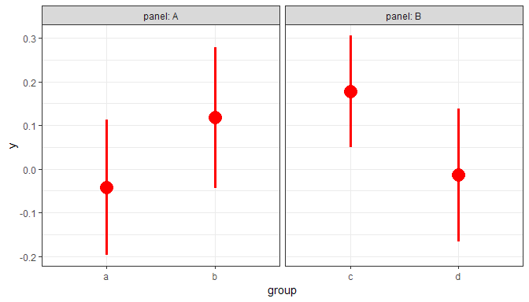

```r
delete_layers(p, idx = 1L)
```

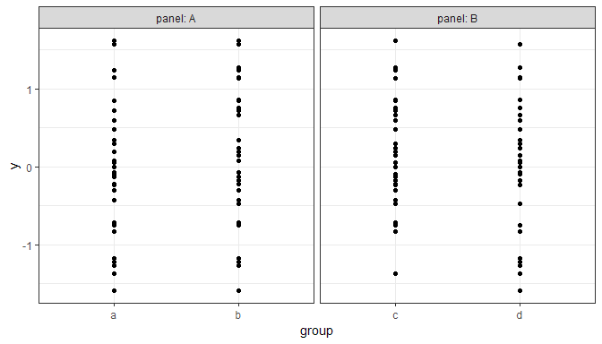

```r
delete_layers(p, "StatSummary")
```

With `move_layers()` we can alter the stacking order of layers. The layers to move are selected in the same way as in the examples above, while `position` gives where to move the layers to. Two character strings, `"top"` and `"bottom"` are accepted as `position` argument, as well as `integer`s. In the later case, the layer(s) is/are appended after the supplied position with reference to the list of layers not being moved.

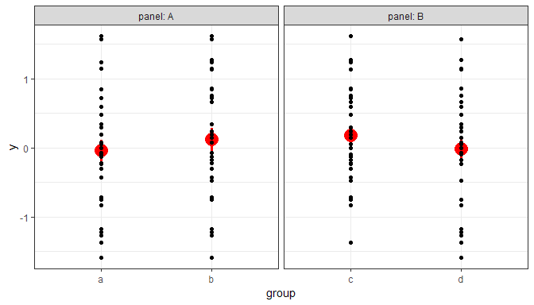

```r
move_layers(p, "GeomPoint", position = "top")
```

The equivalent operation using a relative position. A positive value for `shift` is interpreted as an upward displacement and a negative one as downwards displacement.

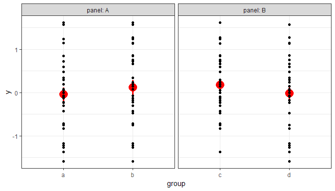

```r
shift_layers(p, "GeomPoint", shift = +1)
```

Here we show how to add a layer behind all other layers.

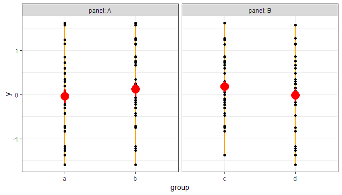

```r
append_layers(p, geom_line(colour = "orange", size = 1), position = "bottom")
```

It is also possible to append the new layer immediately above an arbitrary existing layer using a numeric index, which as shown here can be also obtained by matching to a class name. In this example we insert a new layer in-between two layers already present in the plot. As with the `+` operator of the Grammar of Graphics, `object` also accepts a list of layers as argument (no example shown).

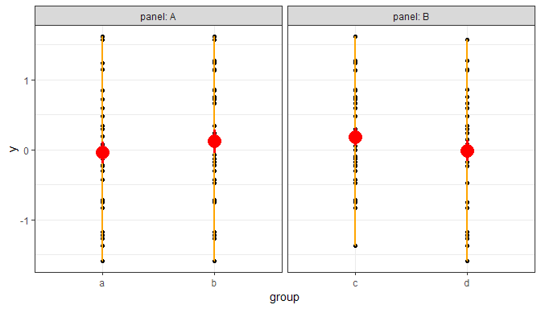

```r
append_layers(p, object = geom_line(colour = "orange", size = 1),
              position = which_layers(p, "GeomPoint"))
```

Annotations add layers, so they can be manipulated in the same way as other layers.

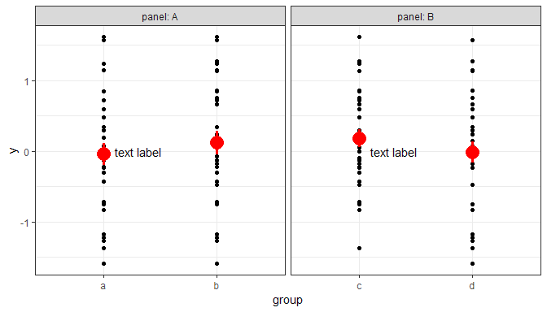

```r
p1 <- p +
  annotate("text", label = "text label", x = 1.1, y = 0, hjust = 0)
p1
```

```r
delete_layers(p1, "GeomText")
```

[output not shown]

## Other manipulations

We very briefly mention in this section how to manipulate other elements of of `ggplot` objects. The output from the examples in this section is not included is this vignette.

For replacing other elements in `ggplot` objects we can in general use methods defined in ‘ggplot2’.

### Editing theme elements

Method `summary()` is available for themes.

```r
summary(theme_bw())
```

However, to see the actual values stored, we need to use `str()`.

```r
str(theme_bw())
```

Themes can be modified using `theme()`. See the ‘ggplot2’ documentation for details.

### Removing unused data

When the data frame passed as data contains many columns and rows, it is stored in whole, even the data columns not mapped to any aesthetic. In many cases this does not matter, but in the case of big datasets, the use of RAM can rapidly add up, and in addition the printing of each plot can slow down significantly. The reason for storing the whole data set is that it is always possible to add layers and consequently only the user can know which variables can be removed or not.

One obvious way out is for the user the select the required columns and pass only these to the ‘ggplot’ constructor. A less efficient alternative, but possibly easier to use for some users, is for users to drop the unused variables when they consider that a plot is ready. We show here how to do this.

```r
mapped.vars <-
  gsub("[~*\\%^]", " ", as.character(p$mapping)) %>%
  str_split(boundary("word")) %>%
  unlist() %>%
  c(names(p$facet$params$facets))
```

We need also to find which variables are present in the data.

```r
data.vars <- names(p$data)
```

Find which variables in data are not used, and delete them from the data.

```r
unused.vars <- setdiff(data.vars, c(mapped.vars))
keep.idxs <- which(!data.vars %in% unused.vars)
```

```r
p1 <- p
p1$data <- p$data[ , keep.idxs]
```

For a data set this small, removing a single column saves little space.

```r
object.size(my.data)
```

```
## 5088 bytes
```

```r
object.size(p)
```

```
## 11384 bytes
```

```r
object.size(p1)
```

```
## 10352 bytes
```

```r
names(my.data)
```

```
## [1] "group"  "panel"  "y"      "unused"
```

```r
names(p$data)
```

```
## [1] "group"  "panel"  "y"      "unused"
```

```r
names(p1$data)
```

```
## [1] "group" "panel" "y"
```

The plot has not changed.

```r
p1
```

We can assemble all the code into a function for convenience, and expand the code to also recognize mappings within layers and variables used in faceting. Such a  
function, only cursorily tested is included in the package as `drop_vars()`. Given its design the most likely failure mode is keeping too many variables rather than removing too many.

```r
drop_vars(p)
```

In principle, one could have expected R not to make a copy of the data in memory for each `ggplot` object, however, the ‘ggplot2’ code seems to modify the argument passed to its `data` parameter triggering a real copy operation. In any case during printing and when saved to disk, even as part of the environment, avoiding to carry along unused data can be beneficial. Of course, removing unused data means that it will not be available if we want to add more layers to the same saved ggplot object after dropping unused variables.